# Lab 4 — Data Analytics with R and ClickHouse

From Data Pipeline to Business Insights

Allan Omondi

02 May 2026

# 1 Introduction

In Parts 1 through 3 you built a complete data engineering pipeline that moves orders from a producer, through Kafka, into PostgreSQL, and then into ClickHouse via Debezium CDC and a custom transformer service.

In this notebook you will use R to:

1. Connect to both databases and inspect the data
2. Perform analytical queries to answer business questions
3. Run the **same query** on PostgreSQL and ClickHouse and measure the performance difference
4. Visualise the results using `ggplot2`

The central argument of this lab is simple: **the data pipeline you built exists because analytical queries do not belong in the operational database.** By the end of this notebook, you will have measured the evidence for that argument directly.

# 2 Setup: Load Libraries and Connect

Run `connect_clickhouse_with_ODBC.R` first to establish `ch_conn` and `pg_conn`. The connection script uses ODBC for ClickHouse. Then run this chunk to confirm both connections are available.

Before you begin: install the R package `odbc`, the **ClickHouse ODBC driver**, and on Linux/macOS the **unixODBC** driver manager. You can confirm that the driver is visible to R by executing: `odbc::odbcListDrivers()`.

```r
library(DBI)
library(RPostgres)
library(odbc)
library(tidyverse)
library(scales)
library(bench)

# These connections must already exist from connect_clickhouse_with_ODBC.R.
# If you see an error here, open connect_clickhouse_with_ODBC.R and run it first.
stopifnot(
  "ch_conn not found — run connect_clickhouse_with_ODBC.R first" = exists("ch_conn"),
  "pg_conn not found — run connect_clickhouse_with_ODBC.R first" = exists("pg_conn")
)

# Confirm row counts
ch_count <- dbGetQuery(ch_conn, "SELECT COUNT(*) AS n FROM orders")$n
pg_count <- dbGetQuery(pg_conn, "SELECT COUNT(*) AS n FROM orders")$n

cat(sprintf("ClickHouse : %s rows\n", format(ch_count, big.mark = ",")))
```

```
ClickHouse : 530469 rows
```

```r
cat(sprintf("PostgreSQL : %s rows\n", format(pg_count, big.mark = ",")))
```

```
PostgreSQL : 500411 rows
```

# 3 Part 1: Exploratory Data Analysis

Before running statistical tests or producing dashboards, the first step in any analytical project is to understand the structure and distribution of the data. This section demonstrates that workflow using the ClickHouse warehouse.

## 3.1 Overview of the Orders Data

```r
# Pull a representative sample for local exploration.
# Note: for summarising the full dataset, we push computation to ClickHouse
# using SQL and only bring the result into R. This is best practice —
# never pull millions of rows into R when a database can compute the
# summary for you. Otherwise, it beats the purpose of the business investing in
# acquiring a powerful database server or data warehouse or data lake.
overview <- dbGetQuery(ch_conn, "
  SELECT
    COUNT(*)                               AS total_orders,
    COUNT(DISTINCT customer_name)          AS unique_customers,
    COUNT(DISTINCT item)                   AS unique_items,
    SUM(order_quantity)                    AS total_units,
    AVG(order_quantity)                    AS avg_quantity_per_order,
    SUM(is_bulk_order)                     AS bulk_orders,
    ROUND(SUM(is_bulk_order) / COUNT(*) * 100, 1) AS bulk_order_pct,
    toTimeZone(MIN(received_at), 'Africa/Nairobi') AS earliest_order,
    toTimeZone(MAX(received_at), 'Africa/Nairobi') AS latest_order
  FROM orders
  WHERE operation != 'DELETE'
")

overview$total_orders            <- as.integer(overview$total_orders)
overview$unique_customers        <- as.integer(overview$unique_customers)
overview$unique_items            <- as.integer(overview$unique_items)
overview$total_units             <- as.integer(overview$total_units)
overview$avg_quantity_per_order  <- as.numeric(overview$avg_quantity_per_order)
overview$bulk_orders             <- as.integer(overview$bulk_orders)
overview$bulk_order_pct          <- as.numeric(overview$bulk_order_pct)

overview$earliest_order <- as.POSIXct(overview$earliest_order, tz = "UTC")
overview$latest_order   <- as.POSIXct(overview$latest_order, tz = "UTC")

overview$earliest_order <- format(
  overview$earliest_order,
  "%Y-%m-%d %H:%M:%S",
  tz = "Africa/Nairobi"
)

overview$latest_order <- format(
  overview$latest_order,
  "%Y-%m-%d %H:%M:%S",
  tz = "Africa/Nairobi"
)

overview_t <- data.frame(
  Metric = names(overview),
  Value  = I(as.list(overview[1, ]))
)

overview_t$Value <- sapply(overview_t$Value, function(x) {
  if (inherits(x, "POSIXct")) {
    format(x, "%Y-%m-%d %H:%M:%S")
  } else if (is.numeric(x)) {
    format(x, scientific = FALSE, big.mark = ",")
  } else {
    as.character(x)
  }
})

print(overview_t)
```

```
                                       Metric               Value
total_orders                     total_orders             611,378
unique_customers             unique_customers                  55
unique_items                     unique_items                  23
total_units                       total_units           6,420,307
avg_quantity_per_order avg_quantity_per_order            10.50137
bulk_orders                       bulk_orders             458,547
bulk_order_pct                 bulk_order_pct                  75
earliest_order                 earliest_order 2026-02-01 20:01:48
latest_order                     latest_order 2026-05-02 20:07:40
```

**Reading the table:** The `bulk_order_pct` shows what proportion of all orders are classified as bulk (quantity > 5). The gap between `earliest_order` and `latest_order` shows the time window covered by the dataset. These are the first questions a data analyst can ask when handed a new dataset.

## 3.2 Order Distribution by Item

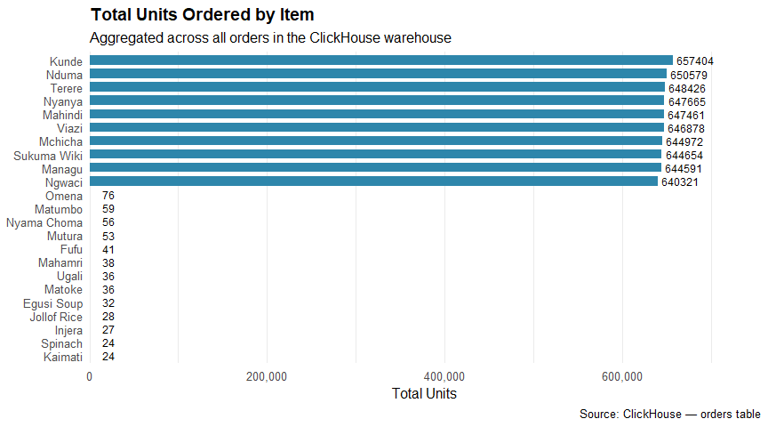

```r
item_summary <- dbGetQuery(ch_conn, "
  SELECT
    item,
    COUNT(*)          AS order_count,
    SUM(order_quantity) AS total_units,
    AVG(order_quantity) AS avg_quantity,
    SUM(is_bulk_order)  AS bulk_orders
  FROM orders
  WHERE operation != 'DELETE'
  GROUP BY item
  ORDER BY total_units DESC
")

ggplot(item_summary, aes(x = reorder(item, total_units), y = total_units)) +
  geom_col(fill = "#2E86AB", width = 0.7) +
  geom_text(
    aes(label = format(total_units, big.mark = ",")),
    hjust = -0.1, size = 3.2
  ) +
  coord_flip() +
  scale_y_continuous(
    labels = comma,
    expand = expansion(mult = c(0, 0.15))
  ) +
  labs(
    title    = "Total Units Ordered by Item",
    subtitle = "Aggregated across all orders in the ClickHouse warehouse",
    x        = NULL,
    y        = "Total Units",
    caption  = "Source: ClickHouse — orders table"
  ) +
  theme_minimal(base_size = 12) +
  theme(
    plot.title    = element_text(face = "bold"),
    panel.grid.major.y = element_blank()
  )
```

## 3.3 Bulk vs Standard Order Breakdown

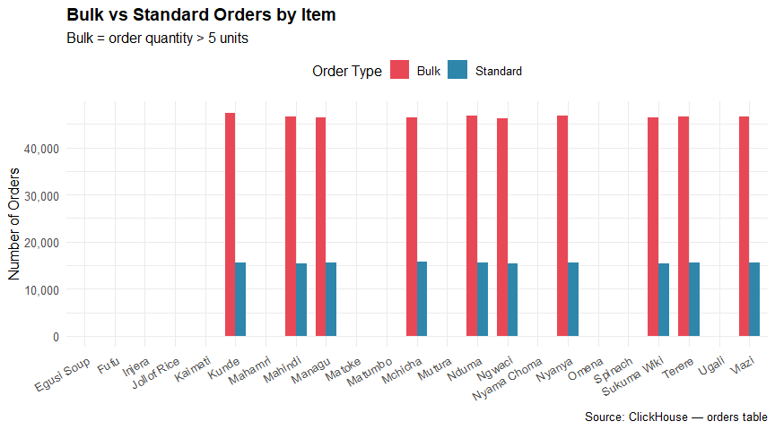

```r
bulk_summary <- dbGetQuery(ch_conn, "
  SELECT
    item,
    SUM(CASE WHEN is_bulk_order = 1 THEN 1 ELSE 0 END) AS bulk,
    SUM(CASE WHEN is_bulk_order = 0 THEN 1 ELSE 0 END) AS standard
  FROM orders
  WHERE operation != 'DELETE'
  GROUP BY item
  ORDER BY item
")

# Reshape to long format for grouped bar chart
bulk_long <- bulk_summary %>%
  pivot_longer(cols = c(bulk, standard),
               names_to  = "order_type",
               values_to = "count") %>%
  mutate(order_type = str_to_title(order_type))

ggplot(bulk_long, aes(x = reorder(item, -count), y = count, fill = order_type)) +
  geom_col(position = "dodge", width = 0.7) +
  scale_fill_manual(
    values = c("Bulk" = "#E84855", "Standard" = "#2E86AB"),
    name   = "Order Type"
  ) +
  scale_y_continuous(labels = comma) +
  labs(
    title    = "Bulk vs Standard Orders by Item",
    subtitle = "Bulk = order quantity > 5 units",
    x        = NULL,
    y        = "Number of Orders",
    caption  = "Source: ClickHouse — orders table"
  ) +
  theme_minimal(base_size = 12) +
  theme(
    plot.title         = element_text(face = "bold"),
    legend.position    = "top",
    axis.text.x        = element_text(angle = 30, hjust = 1)
  )
```

## 3.4 Order Volume Over Time

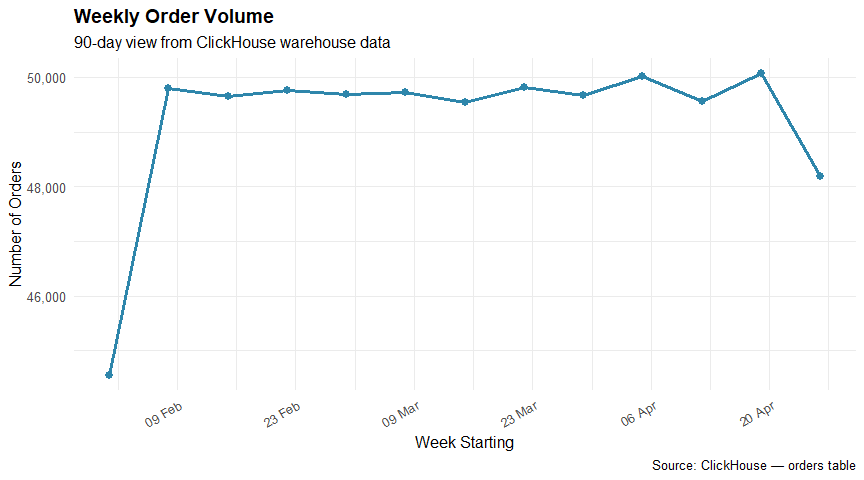

```r
# Aggregate orders by week to show trends over the 90-day period
weekly_orders <- dbGetQuery(ch_conn, "
  SELECT
    toStartOfWeek(received_at)  AS week_start,
    COUNT(*)                     AS order_count,
    SUM(order_quantity)          AS total_units
  FROM orders
  WHERE operation != 'DELETE'
  GROUP BY week_start
  ORDER BY week_start
")

weekly_orders$week_start <- as.Date(weekly_orders$week_start)

ggplot(weekly_orders, aes(x = week_start, y = order_count)) +
  geom_line(colour = "#2E86AB", linewidth = 1.2) +
  geom_point(colour = "#2E86AB", size = 2.5) +
  scale_x_date(date_labels = "%d %b", date_breaks = "2 weeks") +
  scale_y_continuous(labels = comma) +
  labs(
    title    = "Weekly Order Volume",
    subtitle = "90-day view from ClickHouse warehouse data",
    x        = "Week Starting",
    y        = "Number of Orders",
    caption  = "Source: ClickHouse — orders table"
  ) +
  theme_minimal(base_size = 12) +
  theme(
    plot.title   = element_text(face = "bold"),
    axis.text.x  = element_text(angle = 30, hjust = 1)
  )
```

# 4 Part 2: Business Analytics — Hypothesis Tests

A data analyst does not simply describe data. They form hypotheses and test them. This section demonstrates two statistical tests using the orders data.

## 4.1 Hypothesis Test 1: Do Bulk Orders Differ in Quantity?

**Business question:** Do customers who place bulk orders (quantity > 5) place significantly larger orders than customers who place standard orders? Or is the 5-unit threshold arbitrary?

**Hypotheses:**

- H₀: The mean order quantity for bulk orders equals the mean order quantity for standard orders. (μ_bulk = μ_standard)
- H₁: The mean order quantity for bulk orders is greater than for standard orders. (μ_bulk > μ_standard)

```r
# Pull the raw quantities — we need individual records for the t-test
quantities <- dbGetQuery(ch_conn, "
  SELECT order_quantity, is_bulk_order
  FROM orders
  WHERE operation != 'DELETE'
  LIMIT 50000
")

bulk_qty     <- quantities$order_quantity[quantities$is_bulk_order == 1]
standard_qty <- quantities$order_quantity[quantities$is_bulk_order == 0]

cat(sprintf("Bulk orders     : n = %s, mean = %.2f, sd = %.2f\n",
    format(length(bulk_qty), big.mark=","),
    mean(bulk_qty), sd(bulk_qty)))
```

```
Bulk orders     : n = 37,435, mean = 12.99, sd = 4.32
```

```r
cat(sprintf("Standard orders : n = %s, mean = %.2f, sd = %.2f\n",
    format(length(standard_qty), big.mark=","),
    mean(standard_qty), sd(standard_qty)))
```

```
Standard orders : n = 12,565, mean = 3.00, sd = 1.42
```

```r
# One-sided Welch's t-test (does not assume equal variances)
t_result <- t.test(
  bulk_qty,
  standard_qty,
  alternative = "greater",
  var.equal   = FALSE
)

print(t_result)
```

```
    Welch Two Sample t-test

data:  bulk_qty and standard_qty
t = 389.49, df = 49976, p-value < 2.2e-16
alternative hypothesis: true difference in means is greater than 0
95 percent confidence interval:
 9.955741      Inf
sample estimates:
mean of x mean of y
12.993268  2.995304
```

```r
cat("\n--- INTERPRETATION ---\n")
```

```
--- INTERPRETATION ---
```

```r
if (t_result$p.value < 0.05) {
  cat(sprintf(
    "We reject H₀ at the 5%% significance level (p = %.4f).\n",
    t_result$p.value
  ))
  cat("There is statistically significant evidence that bulk orders\n")
  cat("have a higher mean quantity than standard orders.\n")
} else {
  cat(sprintf(
    "We fail to reject H₀ (p = %.4f).\n",
    t_result$p.value
  ))
  cat("There is insufficient evidence of a significant difference.\n")
}
```

```
We reject H₀ at the 5% significance level (p = 0.0000).
There is statistically significant evidence that bulk orders
have a higher mean quantity than standard orders.
```

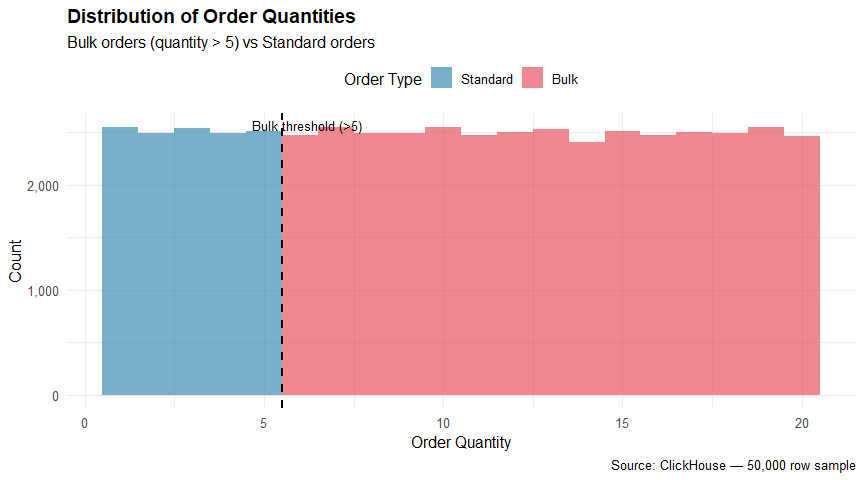

```r
# Visualise the distribution of quantities for both groups
quantities %>%
  mutate(order_type = if_else(is_bulk_order == 1, "Bulk", "Standard"),
         order_type = factor(order_type, levels = c("Standard", "Bulk"))) %>%
  ggplot(aes(x = order_quantity, fill = order_type)) +
  geom_histogram(binwidth = 1, position = "identity", alpha = 0.65) +
  geom_vline(
    xintercept = 5.5, linetype = "dashed",
    colour = "black", linewidth = 0.8
  ) +
  annotate("text", x = 6.2, y = Inf, vjust = 1.5,
           label = "Bulk threshold (>5)", size = 3.5) +
  scale_fill_manual(
    values = c("Standard" = "#2E86AB", "Bulk" = "#E84855"),
    name   = "Order Type"
  ) +
  scale_y_continuous(labels = comma) +
  labs(
    title    = "Distribution of Order Quantities",
    subtitle = "Bulk orders (quantity > 5) vs Standard orders",
    x        = "Order Quantity",
    y        = "Count",
    caption  = "Source: ClickHouse — 50,000 row sample"
  ) +
  theme_minimal(base_size = 12) +
  theme(
    plot.title      = element_text(face = "bold"),
    legend.position = "top"
  )
```

## 4.2 Hypothesis Test 2: Is Order Quantity Independent of Item Type?

**Business question:** Does the type of item ordered influence whether it is a bulk or standard order? Or do customers order all items in roughly equal proportions of bulk and standard?

**Hypotheses:**

- H₀: Order type (bulk vs standard) is independent of item type.
- H₁: There is a significant association between item type and order type.

```r
# Build a contingency table
contingency_data <- dbGetQuery(ch_conn, "
  SELECT
    item,
    SUM(CASE WHEN is_bulk_order = 1 THEN 1 ELSE 0 END) AS bulk,
    SUM(CASE WHEN is_bulk_order = 0 THEN 1 ELSE 0 END) AS standard
  FROM orders
  WHERE operation != 'DELETE'
  GROUP BY item
  ORDER BY item
")

# Convert to matrix for chi-square test
contingency_matrix <- as.matrix(contingency_data[, c("bulk", "standard")])
rownames(contingency_matrix) <- contingency_data$item

cat("Contingency table:\n")
```

```
Contingency table:
```

```r
print(contingency_matrix)
```

```
                     bulk      standard
Egusi Soup  9.881313e-324 2.964394e-323
Fufu        1.976263e-323 1.976263e-323
Injera      9.881313e-324 2.964394e-323
Jollof Rice 9.881313e-324 2.470328e-323
Kaimati     4.940656e-324 3.952525e-323
Kunde       2.477838e-319 8.155542e-320
Mahamri     1.482197e-323 2.964394e-323
Mahindi     2.434311e-319 8.013251e-320
Managu      2.430111e-319 8.119475e-320
Matoke      2.470328e-323 2.470328e-323
Matumbo     2.964394e-323 3.952525e-323
Mchicha     2.430605e-319 8.214829e-320
Mutura      1.976263e-323 4.446591e-323
Nduma       2.449676e-319 8.161964e-320
Ngwaci      2.417266e-319 8.039930e-320
Nyama Choma 2.470328e-323 5.928788e-323
Nyanya      2.445823e-319 8.094277e-320
Omena       3.458460e-323 5.434722e-323
Spinach     9.881313e-324 2.470328e-323
Sukuma Wiki 2.425615e-319 8.050306e-320
Terere      2.445526e-319 8.195067e-320
Ugali       1.976263e-323 3.458460e-323
Viazi       2.435793e-319 8.131332e-320
```

```r
chi_result <- chisq.test(contingency_matrix)
print(chi_result)
```

```
    Pearson's Chi-squared test

data:  contingency_matrix
X-squared = NaN, df = 22, p-value = NA
```

```r
cat("\n--- INTERPRETATION ---\n")
```

```
--- INTERPRETATION ---
```

```r
# -----------------------

expected <- chisq.test(contingency_matrix)$expected

if (any(expected < 5)) {
  warning("Some expected counts are below 5. Chi-square assumptions violated.")
}

# -----------------------

if (is.na(chi_result$p.value)) {
  cat("Chi-square test could not compute a valid p-value.\n")
  cat("This usually happens when expected frequencies are too small\n")
  cat("or when some categories have zero counts.\n")
  cat("Consider combining categories or using Fisher's Exact Test.\n")
} else if (chi_result$p.value < 0.05) {
  cat(sprintf(
    "We reject H₀ at the 5%% significance level (p = %.4f).\n",
    chi_result$p.value
  ))
  cat("There is a statistically significant association between\n")
  cat("item type and whether an order is bulk or standard.\n")
} else {
  cat(sprintf(
    "We fail to reject H₀ (p = %.4f).\n",
    chi_result$p.value
  ))
  cat("Item type and order type appear to be independent.\n")
}
```

```
Chi-square test could not compute a valid p-value.
This usually happens when expected frequencies are too small
or when some categories have zero counts.
Consider combining categories or using Fisher's Exact Test.
```

```r
# Only proceed if chi-square test produced valid residuals
if (!is.null(chi_result$stdres) && !any(is.na(chi_result$stdres))) {

  residuals_df <- as.data.frame(as.table(chi_result$stdres)) %>%
    rename(item = Var1, order_type = Var2, std_residual = Freq) %>%
    mutate(
      order_type = if_else(order_type == "bulk", "Bulk", "Standard"),
      direction  = if_else(std_residual > 0,
                           "Higher than expected",
                           "Lower than expected")
    )

  ggplot(residuals_df, aes(x = item, y = std_residual, fill = direction)) +
    geom_col(width = 0.7) +
    geom_hline(yintercept = c(-2, 2), linetype = "dashed", colour = "grey40") +
    annotate("text", x = 0.5, y =  2.2, label = "+2 threshold", hjust = 0, size = 3) +
    annotate("text", x = 0.5, y = -2.2, label = "−2 threshold", hjust = 0, size = 3) +
    facet_wrap(~order_type) +
    scale_fill_manual(
      values = c(
        "Higher than expected" = "#2E86AB",
        "Lower than expected"  = "#E84855"
      ),
      name = NULL
    ) +
    labs(
      title    = "Chi-Square Standardised Residuals by Item",
      subtitle = "Bars beyond ±2 indicate statistically significant deviation",
      x        = NULL,
      y        = "Standardised Residual",
      caption  = "Source: ClickHouse — orders table"
    ) +
    theme_minimal(base_size = 12) +
    theme(
      plot.title      = element_text(face = "bold"),
      legend.position = "bottom",
      axis.text.x     = element_text(angle = 35, hjust = 1)
    )

} else {

  cat("Residual plot not available.\n")
  cat("Reason: Chi-square test did not produce valid standardised residuals.\n")
  cat("This usually indicates sparse data or violated assumptions.\n")

}
```

```
Residual plot not available.
Reason: Chi-square test did not produce valid standardised residuals.
This usually indicates sparse data or violated assumptions.
```

# 5 Part 3: The Performance Benchmark

This is the central justification for the data pipeline you built. You will now run the **same aggregation query** on PostgreSQL and on ClickHouse and measure the execution time of each.

## 5.1 The Query

The benchmark query computes, for each item, the total number of orders, the total units ordered, the average order quantity, and the bulk order rate. This is a typical OLAP query — it scans every row, reads multiple columns, and produces a grouped aggregation.

```r
# Define the queries for each database.
# The logic is identical — only the column names differ (client_fname vs
# customer_name) because the transformer renamed the field.

PG_QUERY <- "
  SELECT
    item,
    COUNT(*)                              AS order_count,
    SUM(order_quantity)                   AS total_units,
    ROUND(AVG(order_quantity)::numeric, 2) AS avg_quantity,
    SUM(CASE WHEN order_quantity > 5
             THEN 1 ELSE 0 END)           AS bulk_orders,
    ROUND(
      SUM(CASE WHEN order_quantity > 5 THEN 1 ELSE 0 END)::numeric /
      COUNT(*) * 100, 1
    )                                     AS bulk_pct
  FROM orders
  GROUP BY item
  ORDER BY total_units DESC
"

CH_QUERY <- "
  SELECT
    item,
    COUNT(*)                         AS order_count,
    SUM(order_quantity)              AS total_units,
    ROUND(AVG(order_quantity), 2)    AS avg_quantity,
    SUM(is_bulk_order)               AS bulk_orders,
    ROUND(SUM(is_bulk_order) / COUNT(*) * 100, 1) AS bulk_pct
  FROM orders
  WHERE operation != 'DELETE'
  GROUP BY item
  ORDER BY total_units DESC
"

cat("Both queries are defined and ready.\n")
```

```
Both queries are defined and ready.
```

```r
cat("PostgreSQL query will scan:  ", format(pg_count, big.mark=","), " rows\n")
```

```
PostgreSQL query will scan:   500411  rows
```

```r
cat("ClickHouse query will scan:  ", format(ch_count, big.mark=","), " rows\n")
```

```
ClickHouse query will scan:   530469  rows
```

## 5.2 Run the Benchmark

The `bench::mark()` function runs each query multiple times and reports the median, mean, and standard deviation of execution times. Using `bench` rather than `system.time()` produces more reliable results because it controls for CPU caching and JIT effects.

```r
# Warm up both connections with a trivial query before benchmarking.
# This ensures the connection overhead is not included in the timed results.
invisible(dbGetQuery(pg_conn, "SELECT 1"))
invisible(dbGetQuery(ch_conn, "SELECT 1"))

cat("Running benchmark — this may take 1 to 2 minutes...\n")
```

```
Running benchmark — this may take 1 to 2 minutes...
```

```r
cat("Each query runs", 5, "times. Median time is reported.\n\n")
```

```
Each query runs 5 times. Median time is reported.
```

```r
benchmark_results <- bench::mark(
  PostgreSQL  = dbGetQuery(pg_conn, PG_QUERY),
  ClickHouse  = dbGetQuery(ch_conn, CH_QUERY),
  iterations  = 5,
  check       = FALSE   # Results differ (different column names) so skip check
)

# Extract median times for comparison
pg_median <- as.numeric(benchmark_results$median[1])
ch_median <- as.numeric(benchmark_results$median[2])
speedup   <- pg_median / ch_median

cat("\n===== BENCHMARK RESULTS =====\n")
```

```
===== BENCHMARK RESULTS =====
```

```r
cat(sprintf(
  "PostgreSQL  median : %s\n",
  format(benchmark_results$median[1])
))
```

```
PostgreSQL  median : 1.21s
```

```r
cat(sprintf(
  "ClickHouse  median : %s\n",
  format(benchmark_results$median[2])
))
```

```
ClickHouse  median : 547ms
```

```r
cat(sprintf(
  "ClickHouse was %.1f× faster than PostgreSQL\n",
  speedup
))
```

```
ClickHouse was 2.2× faster than PostgreSQL
```

```r
cat("=============================\n")
```

## 5.3 Visualise the Results

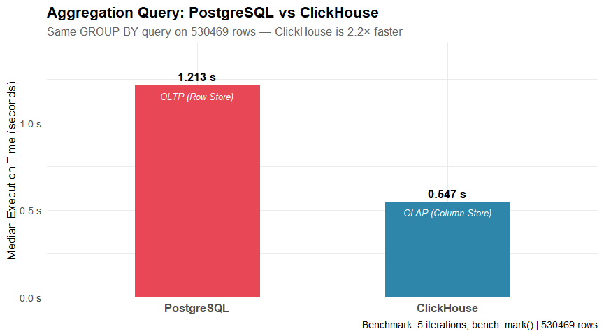

```r
# Build a data frame from the benchmark results for plotting
bench_df <- data.frame(
  database       = c("PostgreSQL", "ClickHouse"),
  median_seconds = c(pg_median, ch_median),
  db_type        = c("OLTP (Row Store)", "OLAP (Column Store)")
)

ggplot(bench_df,
       aes(x = reorder(database, -median_seconds),
           y = median_seconds,
           fill = database)) +
  geom_col(width = 0.5, show.legend = FALSE) +
  geom_text(
    aes(label = sprintf("%.3f s", median_seconds)),
    vjust = -0.5, size = 4.5, fontface = "bold"
  ) +
  geom_text(
    aes(label = db_type),
    vjust = 1.8, size = 3.5, colour = "white", fontface = "italic"
  ) +
  scale_fill_manual(values = c(
    "PostgreSQL"  = "#E84855",
    "ClickHouse"  = "#2E86AB"
  )) +
  scale_y_continuous(
    labels   = label_number(suffix = " s"),
    expand   = expansion(mult = c(0, 0.2))
  ) +
  labs(
    title    = "Aggregation Query: PostgreSQL vs ClickHouse",
    subtitle = sprintf(
      "Same GROUP BY query on %s rows — ClickHouse is %.1f× faster",
      format(max(pg_count, ch_count), big.mark = ","),
      speedup
    ),
    x        = NULL,
    y        = "Median Execution Time (seconds)",
    caption  = paste(
      "Benchmark: 5 iterations, bench::mark()",
      sprintf("| %s rows", format(max(pg_count, ch_count), big.mark = ","))
    )
  ) +
  theme_minimal(base_size = 13) +
  theme(
    plot.title    = element_text(face = "bold"),
    plot.subtitle = element_text(colour = "grey40"),
    axis.text.x   = element_text(size = 12, face = "bold")
  )
```

## 5.4 Examine the Query Results

```r
pg_result <- dbGetQuery(pg_conn, PG_QUERY)
ch_result <- dbGetQuery(ch_conn, CH_QUERY)

knitr::kable(
  pg_result,
  caption   = "Aggregation Result from PostgreSQL",
  col.names = c("Item", "Order Count", "Total Units",
                "Avg Quantity", "Bulk Orders", "Bulk %"),
  format.args = list(big.mark = ",")
)
```

Aggregation Result from PostgreSQL

| Item | Order Count | Total Units | Avg Quantity | Bulk Orders | Bulk % |
| --- | --- | --- | --- | --- | --- |
| Kunde | 50654 | 532398 | 10.51 | 38042 | 75.1 |
| Nduma | 50258 | 527233 | 10.49 | 37662 | 74.9 |
| Terere | 50149 | 526600 | 10.50 | 37570 | 74.9 |
| Mahindi | 49839 | 525462 | 10.54 | 37471 | 75.2 |
| Nyanya | 50090 | 525338 | 10.49 | 37581 | 75.0 |
| Viazi | 49949 | 524535 | 10.50 | 37471 | 75.0 |
| Managu | 50031 | 523770 | 10.47 | 37502 | 75.0 |
| Sukuma Wiki | 49764 | 523691 | 10.52 | 37331 | 75.0 |
| Mchicha | 49851 | 522627 | 10.48 | 37275 | 74.8 |
| Ngwaci | 49726 | 521641 | 10.49 | 37266 | 74.9 |
| Fufu | 85 | 404 | 4.75 | 36 | 42.4 |
| Matumbo | 80 | 382 | 4.78 | 35 | 43.8 |
| Mutura | 76 | 361 | 4.75 | 35 | 46.1 |
| Matoke | 83 | 356 | 4.29 | 28 | 33.7 |
| Jollof Rice | 78 | 352 | 4.51 | 28 | 35.9 |
| Ugali | 73 | 348 | 4.77 | 34 | 46.6 |
| Omena | 70 | 340 | 4.86 | 28 | 40.0 |
| Nyama Choma | 72 | 317 | 4.40 | 26 | 36.1 |
| Egusi Soup | 71 | 309 | 4.35 | 23 | 32.4 |
| Spinach | 69 | 293 | 4.25 | 23 | 33.3 |
| Kaimati | 74 | 291 | 3.93 | 18 | 24.3 |
| Injera | 58 | 255 | 4.40 | 23 | 39.7 |
| Mahamri | 54 | 228 | 4.22 | 16 | 29.6 |

```r
knitr::kable(
  ch_result,
  caption   = "Aggregation Result from ClickHouse",
  col.names = c("Item", "Order Count", "Total Units",
                "Avg Quantity", "Bulk Orders", "Bulk %"),
  format.args = list(big.mark = ",")
)
```

Aggregation Result from ClickHouse

| Item | Order Count | Total Units | Avg Quantity | Bulk Orders | Bulk % |
| --- | --- | --- | --- | --- | --- |
| Kunde | 67338 | 708590 | 10.52 | 50655 | 75.2 |
| Nduma | 66847 | 701783 | 10.50 | 50137 | 75.0 |
| Terere | 66776 | 701423 | 10.50 | 50016 | 74.9 |
| Mahindi | 66199 | 698904 | 10.56 | 49803 | 75.2 |
| Nyanya | 66605 | 698547 | 10.49 | 50032 | 75.1 |
| Viazi | 66444 | 697520 | 10.50 | 49833 | 75.0 |
| Mchicha | 66527 | 696887 | 10.48 | 49732 | 74.8 |
| Sukuma Wiki | 66067 | 695543 | 10.53 | 49603 | 75.1 |
| Managu | 66363 | 695493 | 10.48 | 49737 | 74.9 |
| Ngwaci | 65911 | 691981 | 10.50 | 49460 | 75.0 |
| Omena | 18 | 84 | 4.67 | 7 | 38.9 |
| Nyama Choma | 17 | 68 | 4.00 | 5 | 29.4 |
| Matumbo | 14 | 61 | 4.36 | 6 | 42.9 |
| Mutura | 14 | 57 | 4.07 | 4 | 28.6 |
| Matoke | 10 | 47 | 4.70 | 5 | 50.0 |
| Fufu | 8 | 45 | 5.62 | 4 | 50.0 |
| Ugali | 11 | 44 | 4.00 | 4 | 36.4 |
| Mahamri | 9 | 39 | 4.33 | 3 | 33.3 |
| Egusi Soup | 8 | 32 | 4.00 | 2 | 25.0 |
| Injera | 8 | 28 | 3.50 | 2 | 25.0 |
| Spinach | 7 | 28 | 4.00 | 2 | 28.6 |
| Jollof Rice | 7 | 28 | 4.00 | 2 | 28.6 |
| Kaimati | 9 | 24 | 2.67 | 1 | 11.1 |

## 5.5 Why the Gap Exists: Column Store vs Row Store

```r
cat(
"HOW POSTGRESQL EXECUTES THIS QUERY\n",
"─────────────────────────────────────────────────────────────────────────\n",
"1. Reads every row from disk (all columns: order_id, client_fname,\n",
"   item, order_quantity, received_at).\n",
"2. For each row, extracts only item and order_quantity.\n",
"3. Groups the extracted values and computes the aggregation.\n",
"4. The full row width is read even though only 2 of 5 columns are needed.\n",
"\n",
"HOW CLICKHOUSE EXECUTES THIS QUERY\n",
"─────────────────────────────────────────────────────────────────────────\n",
"1. Reads ONLY the columns referenced in the query:\n",
"   item, order_quantity, is_bulk_order.\n",
"2. These columns are stored contiguously on disk — no row crossing.\n",
"3. ClickHouse also compresses each column independently (similar values\n",
"   compress extremely well — e.g., repeated item names).\n",
"4. The grouped aggregation runs on the compressed column data directly.\n",
"\n",
"The ratio you measured is not an optimisation trick or a lucky cache hit.\n",
"It is a structural consequence of how the data is physically laid out on\n",
"disk. At 10 million rows this gap widens. At 1 billion rows it becomes\n",
"the difference between a 3-second dashboard refresh and a 45-minute wait.\n",
sep = ""
)
```

```
HOW POSTGRESQL EXECUTES THIS QUERY
─────────────────────────────────────────────────────────────────────────
1. Reads every row from disk (all columns: order_id, client_fname,
   item, order_quantity, received_at).
2. For each row, extracts only item and order_quantity.
3. Groups the extracted values and computes the aggregation.
4. The full row width is read even though only 2 of 5 columns are needed.

HOW CLICKHOUSE EXECUTES THIS QUERY
─────────────────────────────────────────────────────────────────────────
1. Reads ONLY the columns referenced in the query:
   item, order_quantity, is_bulk_order.
2. These columns are stored contiguously on disk — no row crossing.
3. ClickHouse also compresses each column independently (similar values
   compress extremely well — e.g., repeated item names).
4. The grouped aggregation runs on the compressed column data directly.

The ratio you measured is not an optimisation trick or a lucky cache hit.
It is a structural consequence of how the data is physically laid out on
disk. At 10 million rows this gap widens. At 1 billion rows it becomes
the difference between a 3-second dashboard refresh and a 45-minute wait.
```

# 6 Part 4: Pipeline Latency Analysis

One of the audit fields the transformer added is `processed_at` — the Nairobi time at which the transformer consumed the Kafka message and wrote the record to ClickHouse. The gap between `received_at` and `processed_at` is the end-to-end pipeline latency.

```r
latency_data <- dbGetQuery(ch_conn, "
  SELECT
    item,
    operation,
    AVG(
      dateDiff('second', received_at, processed_at)
    ) AS avg_latency_seconds,
    MAX(
      dateDiff('second', received_at, processed_at)
    ) AS max_latency_seconds,
    COUNT(*) AS sample_size
  FROM orders
  WHERE operation IN ('INSERT', 'SNAPSHOT')
    AND processed_at > received_at
  GROUP BY item, operation
  ORDER BY avg_latency_seconds DESC
")

knitr::kable(
  latency_data,
  caption   = "Average Pipeline Latency by Item and Operation Type",
  col.names = c("Item", "Operation", "Avg Latency (s)",
                "Max Latency (s)", "Sample Size"),
  format.args = list(big.mark = ","),
  digits = 2
)
```

Average Pipeline Latency by Item and Operation Type

| Item | Operation | Avg Latency (s) | Max Latency (s) | Sample Size |
| --- | --- | --- | --- | --- |
| Nduma | INSERT | 3,906,054.15 | 7780010 | 67132 |
| Kunde | INSERT | 3,897,711.04 | 7780520 | 67608 |
| Viazi | INSERT | 3,889,822.89 | 7777310 | 66707 |
| Sukuma Wiki | INSERT | 3,889,115.41 | 7780970 | 66302 |
| Mahindi | INSERT | 3,885,039.57 | 7779973 | 66471 |
| Ngwaci | INSERT | 3,883,876.94 | 7779597 | 66159 |
| Managu | INSERT | 3,882,603.37 | 7781444 | 66609 |
| Nyanya | INSERT | 3,879,921.30 | 7778052 | 66869 |
| Terere | INSERT | 3,872,439.85 | 7779704 | 67042 |
| Mchicha | INSERT | 3,871,250.12 | 7779835 | 66811 |
| Matoke | INSERT | 3,024.40 | 5494 | 5 |
| Nyama Choma | INSERT | 2,979.29 | 4730 | 7 |
| Spinach | INSERT | 2,881.67 | 5485 | 6 |
| Mutura | INSERT | 2,870.88 | 5116 | 8 |
| Ugali | INSERT | 2,382.57 | 4182 | 7 |
| Injera | INSERT | 2,344.00 | 4480 | 3 |
| Jollof Rice | INSERT | 2,339.20 | 5490 | 5 |
| Matumbo | INSERT | 1,972.00 | 4296 | 6 |
| Egusi Soup | INSERT | 1,965.40 | 3416 | 5 |
| Mahamri | INSERT | 1,941.00 | 4249 | 5 |
| Omena | INSERT | 1,660.50 | 4605 | 6 |
| Fufu | INSERT | 1,443.40 | 4396 | 5 |
| Kaimati | INSERT | 1,016.40 | 1511 | 5 |
| Injera | SNAPSHOT | 141.00 | 141 | 4 |
| Kaimati | SNAPSHOT | 140.75 | 141 | 4 |
| Jollof Rice | SNAPSHOT | 140.33 | 141 | 3 |
| Sukuma Wiki | SNAPSHOT | 130.67 | 140 | 3 |
| Nyanya | SNAPSHOT | 127.00 | 141 | 7 |
| Omena | SNAPSHOT | 126.64 | 141 | 11 |
| Mahindi | SNAPSHOT | 126.20 | 141 | 5 |
| Matumbo | SNAPSHOT | 123.00 | 141 | 7 |
| Matoke | SNAPSHOT | 121.00 | 141 | 6 |
| Egusi Soup | SNAPSHOT | 114.67 | 141 | 3 |
| Mahamri | SNAPSHOT | 114.50 | 141 | 4 |
| Mutura | SNAPSHOT | 111.00 | 141 | 6 |
| Nyama Choma | SNAPSHOT | 110.11 | 141 | 9 |
| Ugali | SNAPSHOT | 107.75 | 141 | 4 |
| Managu | SNAPSHOT | 107.00 | 141 | 8 |
| Fufu | SNAPSHOT | 102.67 | 141 | 3 |
| Spinach | SNAPSHOT | 85.00 | 98 | 2 |

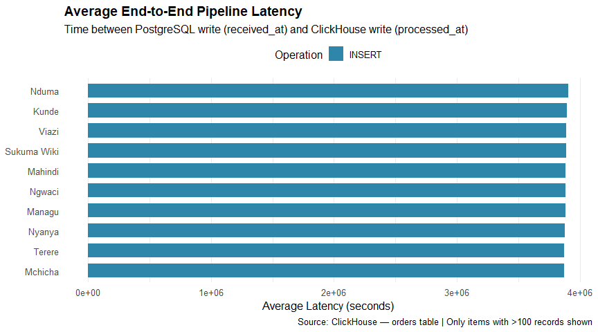

```r
latency_data %>%
  filter(sample_size > 100) %>%
  ggplot(aes(x = reorder(item, avg_latency_seconds),
             y = avg_latency_seconds,
             fill = operation)) +
  geom_col(position = "dodge", width = 0.7) +
  coord_flip() +
  scale_fill_manual(
    values = c("INSERT" = "#2E86AB", "SNAPSHOT" = "#F4A261"),
    name   = "Operation"
  ) +
  labs(
    title    = "Average End-to-End Pipeline Latency",
    subtitle = "Time between PostgreSQL write (received_at) and ClickHouse write (processed_at)",
    x        = NULL,
    y        = "Average Latency (seconds)",
    caption  = "Source: ClickHouse — orders table | Only items with >100 records shown"
  ) +
  theme_minimal(base_size = 12) +
  theme(
    plot.title         = element_text(face = "bold"),
    panel.grid.major.y = element_blank(),
    legend.position    = "top"
  )
```

# 7 Conclusion

The full architecture you have built across Part 1 through 4 — from Kafka producer to ClickHouse analytics — is a simplified but architecturally faithful representation of how data platforms are built in production environments.

# 8 Clean Up

Always close database connections when you are finished.

```r
dbDisconnect(ch_conn)
dbDisconnect(pg_conn)

cat("✅ Both connections closed.\n")
```

```
✅ Both connections closed.
```